# Lab 3

Author

Emily Mitchell

Published

March 7, 2025

```r
library(tidyverse)
library(flextable)
library(zoo)
```

## Question 1: Open data is valuable because it helps enable informed decision making and adaptaion to climate change. Easy access to data also supports sustainable resource managment and the early detection of environmental health risks.

## Question 2.1

```r
url = "https://raw.githubusercontent.com/nytimes/covid-19-data/master/us-counties.csv"
covid_data = read_csv(url)
```

## 2.2

```r
txt <- "2022-02-01"
class(txt)
```

```
[1] "character"
```

```r
date_example <- as.Date(txt)
class(date_example)
```

```
[1] "Date"
```

```r
my.date <- as.Date("2022-02-01")
my.state <- "Colorado"
```

## 2.3

```r
colorado <- covid_data %>%
  filter(state == my.state) %>%
  group_by(county) %>%
  arrange(date) %>%
  mutate(new_cases = cases - lag(cases), new_deaths = deaths - lag(deaths)) %>%
  ungroup()
```

## 2.4

```r
filter(colorado, date == my.date) %>%
  slice_max(cases, n = 5) %>%
  select(Date = date, County = county, Cases = cases) %>%
  flextable() %>%
  add_header_lines("Most Cumulative Cases in Colorado")
```

| Most Cumulative Cases in Colorado Date | Most Cumulative Cases in Colorado County | Most Cumulative Cases in Colorado Cases |
| --- | --- | --- |
| 2022-02-01 | El Paso | 170,673 |
| 2022-02-01 | Denver | 159,022 |
| 2022-02-01 | Arapahoe | 144,255 |
| 2022-02-01 | Adams | 126,768 |
| 2022-02-01 | Jefferson | 113,240 |

```r
filter(colorado, date == my.date) %>%
  slice_max(cases, n = 5) %>%
  select(Date = date, County = county, Cases = new_cases) %>%
  flextable() %>%
  add_header_lines("Most New Cases In Colorado")
```

[output not shown]

## Question 3.1

```r
pop_url <- 'https://www2.census.gov/programs-surveys/popest/datasets/2020-2023/counties/totals/co-est2023-alldata.csv'
pop_data <- read_csv(pop_url) %>%
  filter(COUNTY != "000") %>%
  mutate(fips = sprintf("%05s", paste0(STATE, COUNTY))) %>%
  select(fips, contains("NAME"), contains("2021"))
head(pop_data, 5)
```

```
# A tibble: 5 × 19
  fips  STNAME  CTYNAME        POPESTIMATE2021 NPOPCHG2021 BIRTHS2021 DEATHS2021
  <chr> <chr>   <chr>                    <dbl>       <dbl>      <dbl>      <dbl>
1 01001 Alabama Autauga County           59203         288        686        696
2 01003 Alabama Baldwin County          239439        6212       2337       2948
3 01005 Alabama Barbour County           24533        -436        270        390
4 01007 Alabama Bibb County              22359         171        240        325
5 01009 Alabama Blount County            59079         -28        654        875
# ℹ 12 more variables: NATURALCHG2021 <dbl>, INTERNATIONALMIG2021 <dbl>,
#   DOMESTICMIG2021 <dbl>, NETMIG2021 <dbl>, RESIDUAL2021 <dbl>,
#   GQESTIMATES2021 <dbl>, RBIRTH2021 <dbl>, RDEATH2021 <dbl>,
#   RNATURALCHG2021 <dbl>, RINTERNATIONALMIG2021 <dbl>, RDOMESTICMIG2021 <dbl>,
#   RNETMIG2021 <dbl>
```

## 3.2 Explore the data. In a few sentences describe the data obtained after modification. The data frame has 3,144 rows and 19 columns. Information related to county, state, and fips is present in both the population data and the COVID data.

```r
names(pop_data)
```

```
 [1] "fips"                  "STNAME"                "CTYNAME"
 [4] "POPESTIMATE2021"       "NPOPCHG2021"           "BIRTHS2021"
 [7] "DEATHS2021"            "NATURALCHG2021"        "INTERNATIONALMIG2021"
[10] "DOMESTICMIG2021"       "NETMIG2021"            "RESIDUAL2021"
[13] "GQESTIMATES2021"       "RBIRTH2021"            "RDEATH2021"
[16] "RNATURALCHG2021"       "RINTERNATIONALMIG2021" "RDOMESTICMIG2021"
[19] "RNETMIG2021"
```

```r
dim(pop_data)
```

```
[1] 3144   19
```

```r
glimpse(pop_data)
```

```
Rows: 3,144
Columns: 19
$ fips                  <chr> "01001", "01003", "01005", "01007", "01009", "01…
$ STNAME                <chr> "Alabama", "Alabama", "Alabama", "Alabama", "Ala…
$ CTYNAME               <chr> "Autauga County", "Baldwin County", "Barbour Cou…
$ POPESTIMATE2021       <dbl> 59203, 239439, 24533, 22359, 59079, 10143, 18890…
$ NPOPCHG2021           <dbl> 288, 6212, -436, 171, -28, -86, -135, -565, -163…
$ BIRTHS2021            <dbl> 686, 2337, 270, 240, 654, 111, 227, 1250, 392, 2…
$ DEATHS2021            <dbl> 696, 2948, 390, 325, 875, 160, 297, 1843, 592, 4…
$ NATURALCHG2021        <dbl> -10, -611, -120, -85, -221, -49, -70, -593, -200…
$ INTERNATIONALMIG2021  <dbl> 15, 105, 0, 1, 9, 1, 5, 12, 22, 7, 20, 1, 0, -1,…
$ DOMESTICMIG2021       <dbl> 242, 6972, -313, 254, 141, -42, -75, -70, -6, 28…
$ NETMIG2021            <dbl> 257, 7077, -313, 255, 150, -41, -70, -58, 16, 29…
$ RESIDUAL2021          <dbl> 41, -254, -3, 1, 43, 4, 5, 86, 21, 2, 18, 7, 8, …
$ GQESTIMATES2021       <dbl> 484, 3351, 2248, 1994, 616, 1578, 285, 5407, 856…
$ RBIRTH2021            <dbl> 11.615503, 9.888589, 10.908650, 10.775136, 11.06…
$ RDEATH2021            <dbl> 11.78483, 12.47392, 15.75694, 14.59133, 14.80717…
$ RNATURALCHG2021       <dbl> -0.1693222, -2.5853351, -4.8482890, -3.8161941, …
$ RINTERNATIONALMIG2021 <dbl> 0.25398330, 0.44428836, 0.00000000, 0.04489640, …
$ RDOMESTICMIG2021      <dbl> 4.0975973, 29.5007468, -12.6459537, 11.4036860, …
$ RNETMIG2021           <dbl> 4.3515806, 29.9450352, -12.6459537, 11.4485824, …
```

## 3.3 What is the range of populations seen in Colorado counties in 2021? The range of populations seen in Colorado counties in 2021 was 736,546.

```r
colorado_pop <- pop_data |>
  filter(STNAME == "Colorado") |>
  summarize(min_pop = min(POPESTIMATE2021, na.rm = TRUE),
            max_pop = max(POPESTIMATE2021, na.rm = TRUE),
            range_pop = max_pop - min_pop)
print(colorado_pop)
```

```
# A tibble: 1 × 3
  min_pop max_pop range_pop
    <dbl>   <dbl>     <dbl>
1     741  737287    736546
```

# Question 3.4 Join the population data to the Colorado COVID data and compute the per capita cumulative cases, per capita new cases, and per capita new deaths:

```r
pop_url <- 'https://www2.census.gov/programs-surveys/popest/datasets/2020-2023/counties/totals/co-est2023-alldata.csv'
pop_joined <- read_csv(pop_url) %>%
  filter(COUNTY != "000") %>%
  mutate(fips = sprintf("%05s", paste0(STATE, COUNTY))) %>%
  right_join(colorado) %>%
  select(fips, date, cases, deaths, contains("NAME"), contains("2021")) %>%
  group_by(fips) %>%
  arrange(fips, date) %>%
  mutate(new_cases = cases - lag(cases), new_deaths = deaths - lag(deaths)) %>%
  ungroup()
```

```r
percap <- pop_joined %>%
  filter(date == my.date) %>%
  mutate(per_cap_cases = cases / POPESTIMATE2021,
            per_cap_new = new_cases / POPESTIMATE2021,
            per_cap_deaths = deaths / POPESTIMATE2021)
```

# Question 3.5 Generate (2) new tables. The first should show the 5 counties with the most cumulative cases per capita on 2021-01-01, and the second should show the 5 counties with the most NEW cases per capita on the same date. Your tables should have clear column names and descriptive captions.

```r
percap %>%
  slice_max(per_cap_cases, n = 5) %>%
  select(CTYNAME, per_cap_cases) %>%
  flextable() %>%
  add_header_lines("Counties with Most Cumulative Covid Cases Per Capita")
```

| Counties with Most Cumulative Covid Cases Per Capita CTYNAME | Counties with Most Cumulative Covid Cases Per Capita per_cap_cases |
| --- | --- |
| Crowley County | 0.5117698 |
| Bent County | 0.4118749 |
| Pitkin County | 0.3429659 |
| Lincoln County | 0.3424082 |
| Logan County | 0.3047701 |

```r
percap %>%
  slice_max(per_cap_new, n = 5) %>%
  select(CTYNAME, per_cap_new) %>%
  flextable() %>%
  add_header_lines("Counties With Most New COVID Cases Per Capita")
```

| Counties With Most New COVID Cases Per Capita CTYNAME | Counties With Most New COVID Cases Per Capita per_cap_new |
| --- | --- |
| Crowley County | 0.009764603 |
| Bent County | 0.004120622 |
| Sedgwick County | 0.003869304 |
| Washington County | 0.002875924 |
| Las Animas County | 0.002651039 |

```r
percap %>%
  slice_max(per_cap_deaths, n = 5) %>%
  select(CTYNAME, per_cap_deaths) %>%
  flextable() %>%
  add_header_lines("Counties With Most New COVID Deaths Per Capita")
```

[output not shown]

## Question 4 Filter the merged COVID/Population data to only include the last 14 days. Remember this should be a programmatic request and not hard-coded. Then, use the group_by/summarize paradigm to determine the total number of new cases in the last 14 days per 100,000 people. Print a table of the top 5 counties, and, report the number that meet the watch list condition: “More than 100 new cases per 100,000 residents over the past 14 days…”

## All counties in CO meet the watch list conditions.

```r
filtered_date <- pop_joined %>%
  filter(date >= (my.date - 13))

county_summary <- filtered_date %>%
  group_by(CTYNAME) %>%
  summarize(total_new_cases = sum(new_cases, na.rm = TRUE),
            population = first(POPESTIMATE2021)) %>%
  mutate(cases_per_100k = (total_new_cases / population) * 100000) %>%
  arrange(desc(cases_per_100k))

top_5_table <- county_summary %>%
  slice_head(n = 5) %>%
  select(CTYNAME, cases_per_100k) %>%
  flextable() %>%
  add_header_lines("Counties with most new COVID cases per 100,000 people for the last 14 days")

print(top_5_table)
```

```
a flextable object.
col_keys: `CTYNAME`, `cases_per_100k`
header has 2 row(s)
body has 5 row(s)
original dataset sample:
         CTYNAME cases_per_100k
1 Crowley County      11107.236
2 Lincoln County       9537.731
3    Bent County       9421.240
4 Fremont County       7742.145
5   Logan County       7378.844
```

```r
watchlist_count <- county_summary %>%
  filter(cases_per_100k > 100) %>%
  nrow()

print(watchlist_count)
```

```
[1] 64
```

## Question 5 Given we are assuming it is February 1st, 2022. Your leadership has asked you to determine what percentage of deaths in each county were attributed to COVID last year (2021).

```r
library(lubridate)
date_2021 <- pop_joined %>%
  filter(year(date) == 2021)
covid_2021 <- date_2021 %>%
  group_by(CTYNAME) %>%
  summarize(total_covid_deaths = max(deaths, na.rm = TRUE))
```

```r
deaths_by_county <- pop_joined %>%
  group_by(CTYNAME) %>%
  reframe(total_deaths = DEATHS2021) %>%
  distinct()
```

```r
merged_2021 <- covid_2021 %>%
  inner_join(deaths_by_county, by = "CTYNAME")
```

```r
merged_2021 <- merged_2021 %>%
  mutate(covid_percentage = (total_covid_deaths / total_deaths) * 100)
```

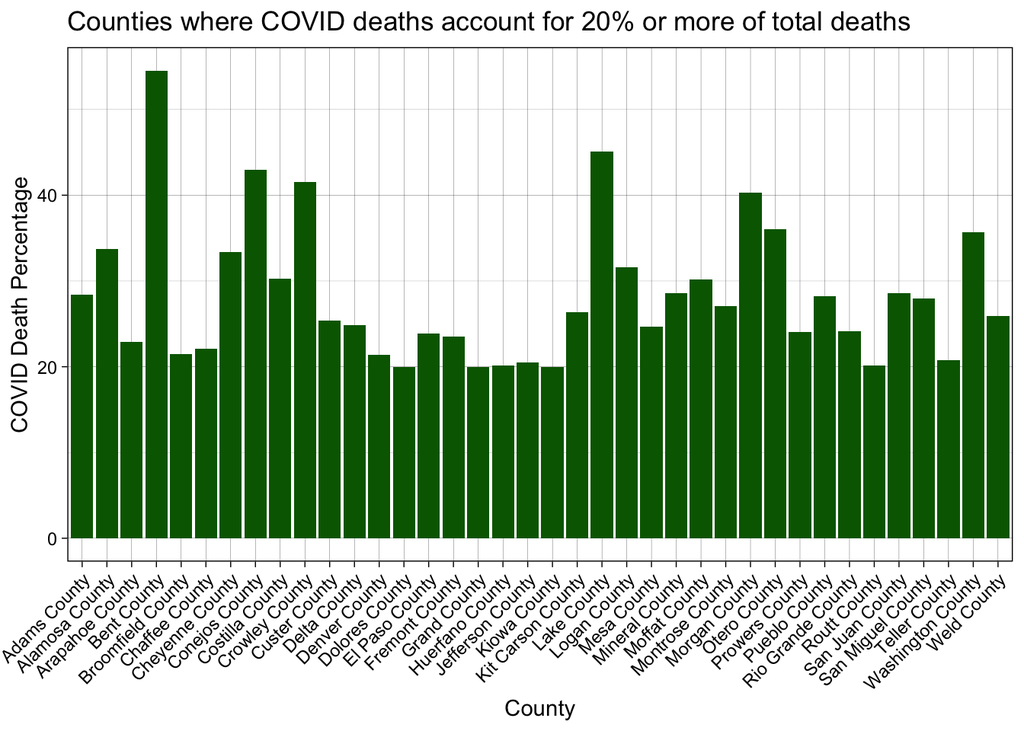

```r
filtered_2021 <- merged_2021 %>%
  filter(covid_percentage >= 20)

ggplot(filtered_2021, aes(x = CTYNAME, y = covid_percentage)) +
  geom_bar(stat = "identity", fill = "darkgreen") +
  labs(
    title = "Counties where COVID deaths account for 20% or more of total deaths",
    x = "County",
    y = "COVID Death Percentage"
  ) +
  theme_linedraw() +
  theme(axis.text.x = element_text(angle = 45, hjust = 1))
```

```r
print(plot)
```

[output not shown]

##Question 6 In this question, we are going to look at the story of 4 states and the impact scale can have on data interpretation. The states include: New York, Colorado, Alabama, and Ohio. Your task is to make a faceted bar plot showing the number of daily, new cases at the state level.

## 6.1

```r
state_data <- covid_data %>%
  group_by(date, state) %>%
  summarize(total_cases = sum(cases), .groups = "drop") %>%
  filter(state %in% c("New York", "Colorado", "Alabama", "Ohio")) %>%
  group_by(state) %>%
  mutate(new_cases = total_cases - lag(total_cases), rolling_mean = rollmean(new_cases, k = 7, fill = NA, align = "right")) %>%
  ungroup()
```

## 6.2

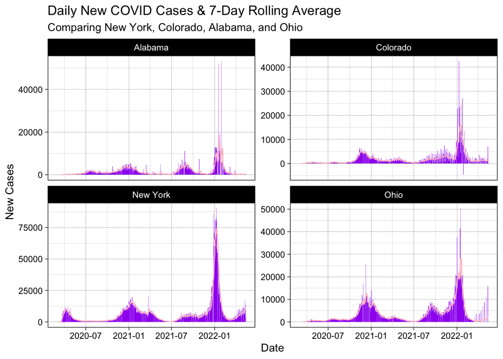

```r
ggplot(state_data, aes(x = date)) +
  geom_col(aes(y = new_cases), fill = "purple", col = NA) +
  geom_line(aes(y = rolling_mean), col = "pink") +
  theme_linedraw()+
  facet_wrap(~ state, nrow = 2, scales = "free_y") +
  labs(title = "Daily New COVID Cases & 7-Day Rolling Average",
       subtitle = "Comparing New York, Colorado, Alabama, and Ohio",
       x = "Date",
       y = "New Cases",
       color = "Legend")
```

```r
print(plot)
```

[output not shown]

## 6.3

```r
popp <- pop_data %>%
  group_by(STNAME) %>%
  summarise(state_pop = sum(POPESTIMATE2021)) %>%
  inner_join(state_data, by = c("STNAME"="state")) %>%
  mutate(perCap = new_cases / state_pop) %>%
  group_by(STNAME) %>%
  mutate(rolling_avg_percap = zoo::rollmean(perCap, k = 7, align = "right", fill = NA)) %>%
  ungroup()

print(popp, n = 5)
```

```
# A tibble: 3,192 × 8
  STNAME  state_pop date       total_cases new_cases rolling_mean      perCap
  <chr>       <dbl> <date>           <dbl>     <dbl>        <dbl>       <dbl>
1 Alabama   5050380 2020-03-13           6        NA           NA NA
2 Alabama   5050380 2020-03-14          12         6           NA  0.00000119
3 Alabama   5050380 2020-03-15          23        11           NA  0.00000218
4 Alabama   5050380 2020-03-16          29         6           NA  0.00000119
5 Alabama   5050380 2020-03-17          39        10           NA  0.00000198
# ℹ 3,187 more rows
# ℹ 1 more variable: rolling_avg_percap <dbl>
```

## 6.4

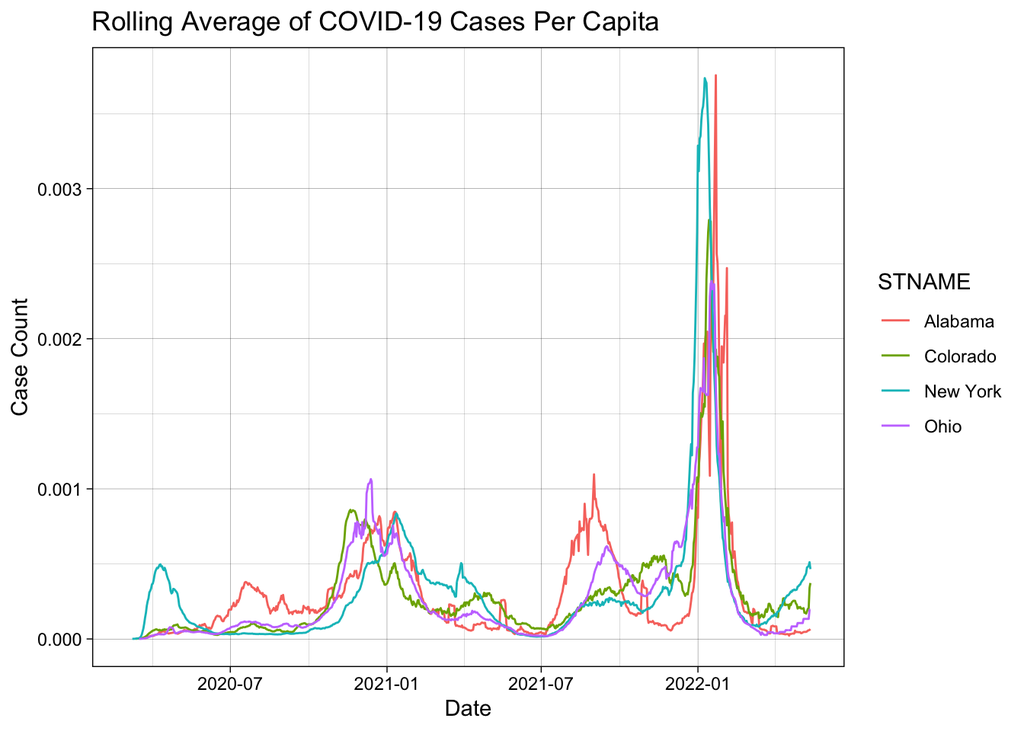

```r
ggplot(popp, aes(x = date)) +
  geom_line(aes(y = rolling_avg_percap, col = STNAME)) +
  theme_linedraw() +
  labs(title = "Rolling Average of COVID-19 Cases Per Capita",
       x = "Date", y = "Case Count")
```

```r
print(plot)
```

[output not shown]

## Question 7 We will calculate the Weighted Mean Center of the COVID-19 outbreak in the USA to better understand the movement of the virus through time. Describe the movement of the COVID-19 weighted mean throughout the USA and possible drivers of its movement given your knowledge of the outbreak hot spots.

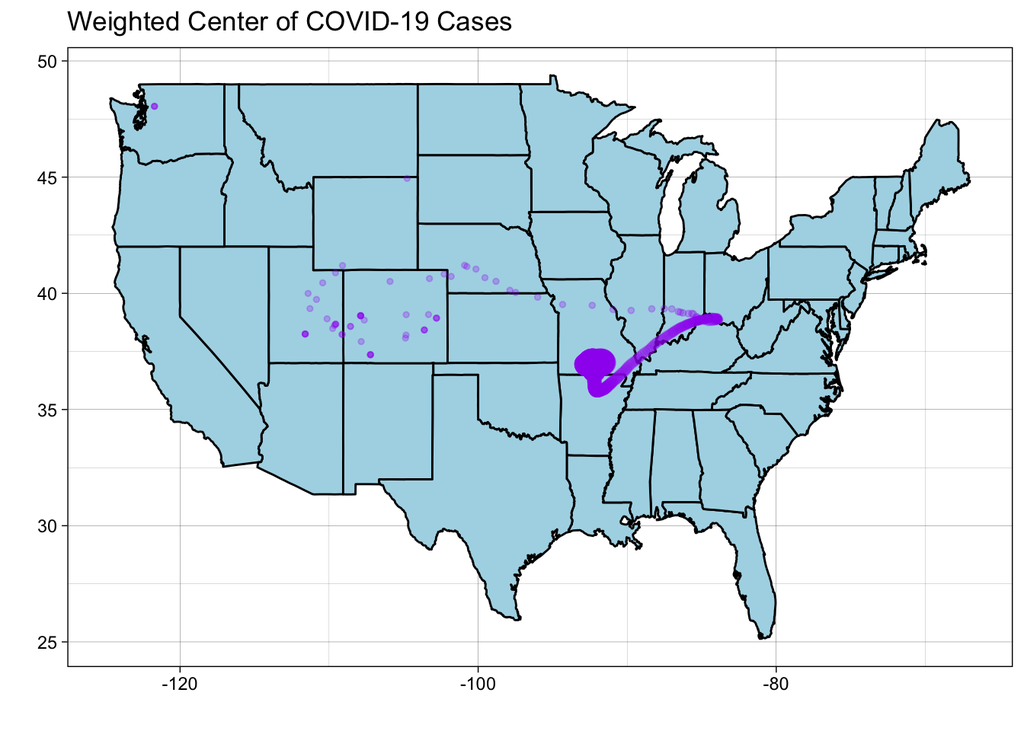

```r
meta = read_csv('https://raw.githubusercontent.com/mikejohnson51/csu-ess-330/refs/heads/main/resources/county-centroids.csv') %>%
  inner_join(covid_data) %>%
  group_by(date) %>%
  summarise(wmX_c = sum(LON*cases) / sum(cases),
             wmY_c = sum(LAT*cases) / sum(cases),
             cases = sum(cases)) %>%
  arrange(date) %>%
  mutate(d = 1:n())

ggplot(meta) +
  borders("state",fill = "lightblue", colour = "black") +
  geom_point(aes(x = wmX_c, y = wmY_c, size = cases), color = "purple", alpha = .25) +
  theme_linedraw() +
  labs(size = "Cases",
       x = "", y = "",
       title = "Weighted Center of COVID-19 Cases") +
  theme(legend.position = "none")
```

```r
print(plot)
```

[output not shown]